# W3cubDocs

/scikit-learn

# sklearn.cluster.AgglomerativeClustering

**`class sklearn.cluster.AgglomerativeClustering(n_clusters=2, affinity=’euclidean’, memory=None, connectivity=None, compute_full_tree=’auto’, linkage=’ward’, pooling_func=’deprecated’)` [[source]](https://github.com/scikit-learn/scikit-learn/blob/bac89c2/sklearn/cluster/hierarchical.py#L656)**

Agglomerative Clustering

Recursively merges the pair of clusters that minimally increases a given linkage distance.

Read more in the User Guide.

Parameters:

**`n_clusters : int, default=2`**

The number of clusters to find.

**`affinity : string or callable, default: “euclidean”`**

Metric used to compute the linkage. Can be “euclidean”, “l1”, “l2”, “manhattan”, “cosine”, or ‘precomputed’. If linkage is “ward”, only “euclidean” is accepted.

**`memory : None, str or object with the joblib.Memory interface, optional`**

Used to cache the output of the computation of the tree. By default, no caching is done. If a string is given, it is the path to the caching directory.

**`connectivity : array-like or callable, optional`**

Connectivity matrix. Defines for each sample the neighboring samples following a given structure of the data. This can be a connectivity matrix itself or a callable that transforms the data into a connectivity matrix, such as derived from kneighbors_graph. Default is None, i.e, the hierarchical clustering algorithm is unstructured.

**`compute_full_tree : bool or ‘auto’ (optional)`**

Stop early the construction of the tree at n_clusters. This is useful to decrease computation time if the number of clusters is not small compared to the number of samples. This option is useful only when specifying a connectivity matrix. Note also that when varying the number of clusters and using caching, it may be advantageous to compute the full tree.

**`linkage : {“ward”, “complete”, “average”, “single”}, optional (default=”ward”)`**

Which linkage criterion to use. The linkage criterion determines which distance to use between sets of observation. The algorithm will merge the pairs of cluster that minimize this criterion.

- ward minimizes the variance of the clusters being merged.
- average uses the average of the distances of each observation of the two sets.
- complete or maximum linkage uses the maximum distances between all observations of the two sets.
- single uses the minimum of the distances between all observations of the two sets.

**`pooling_func : callable, default=’deprecated’`**

Ignored.

Deprecated since version 0.20: `pooling_func` has been deprecated in 0.20 and will be removed in 0.22.

Attributes:

**`labels_ : array [n_samples]`**

cluster labels for each point

**`n_leaves_ : int`**

Number of leaves in the hierarchical tree.

**`n_components_ : int`**

The estimated number of connected components in the graph.

**`children_ : array-like, shape (n_samples-1, 2)`**

The children of each non-leaf node. Values less than `n_samples` correspond to leaves of the tree which are the original samples. A node `i` greater than or equal to `n_samples` is a non-leaf node and has children `children_[i - n_samples]`. Alternatively at the i-th iteration, children[i][0] and children[i][1] are merged to form node `n_samples + i`

#### Examples

```
>>> from sklearn.cluster import AgglomerativeClustering
>>> import numpy as np
>>> X = np.array([[1, 2], [1, 4], [1, 0],
...               [4, 2], [4, 4], [4, 0]])
>>> clustering = AgglomerativeClustering().fit(X)
>>> clustering
AgglomerativeClustering(affinity='euclidean', compute_full_tree='auto',
            connectivity=None, linkage='ward', memory=None, n_clusters=2,
            pooling_func='deprecated')
>>> clustering.labels_
array([1, 1, 1, 0, 0, 0])
```

#### Methods

| `fit`(X[, y]) | Fit the hierarchical clustering on the data |
| --- | --- |
| `fit_predict`(X[, y]) | Performs clustering on X and returns cluster labels. |
| `get_params`([deep]) | Get parameters for this estimator. |
| `set_params`(**params) | Set the parameters of this estimator. |

**`__init__(n_clusters=2, affinity=’euclidean’, memory=None, connectivity=None, compute_full_tree=’auto’, linkage=’ward’, pooling_func=’deprecated’)` [[source]](https://github.com/scikit-learn/scikit-learn/blob/bac89c2/sklearn/cluster/hierarchical.py#L752)**

**`fit(X, y=None)` [[source]](https://github.com/scikit-learn/scikit-learn/blob/bac89c2/sklearn/cluster/hierarchical.py#L764)**

Fit the hierarchical clustering on the data

| Parameters: | **`X : array-like, shape = [n_samples, n_features]`** Training data. Shape [n_samples, n_features], or [n_samples, n_samples] if affinity==’precomputed’. **`y : Ignored`** |
| --- | --- |
| Returns: | **self** |

**`fit_predict(X, y=None)` [[source]](https://github.com/scikit-learn/scikit-learn/blob/bac89c2/sklearn/base.py#L337)**

Performs clustering on X and returns cluster labels.

| Parameters: | **`X : ndarray, shape (n_samples, n_features)`** Input data. **`y : Ignored`** not used, present for API consistency by convention. |
| --- | --- |
| Returns: | **`labels : ndarray, shape (n_samples,)`** cluster labels |

**`get_params(deep=True)` [[source]](https://github.com/scikit-learn/scikit-learn/blob/bac89c2/sklearn/base.py#L166)**

Get parameters for this estimator.

| Parameters: | **`deep : boolean, optional`** If True, will return the parameters for this estimator and contained subobjects that are estimators. |
| --- | --- |
| Returns: | **`params : mapping of string to any`** Parameter names mapped to their values. |

**`set_params(**params)` [[source]](https://github.com/scikit-learn/scikit-learn/blob/bac89c2/sklearn/base.py#L189)**

Set the parameters of this estimator.

The method works on simple estimators as well as on nested objects (such as pipelines). The latter have parameters of the form `<component>__<parameter>` so that it’s possible to update each component of a nested object.

| Returns: | **self** |
| --- | --- |

## Examples using `sklearn.cluster.AgglomerativeClustering`

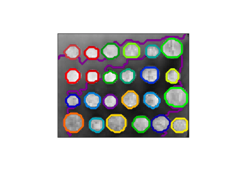

A demo of structured Ward hierarchical clustering on an image of coins

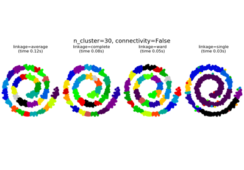

Agglomerative clustering with and without structure

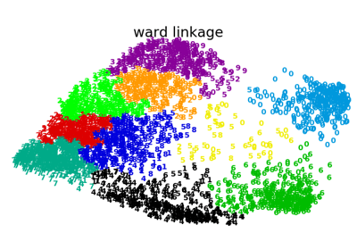

Various Agglomerative Clustering on a 2D embedding of digits

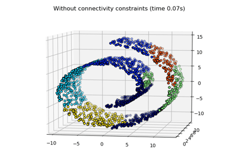

Hierarchical clustering: structured vs unstructured ward

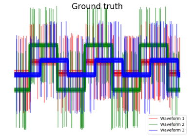

Agglomerative clustering with different metrics

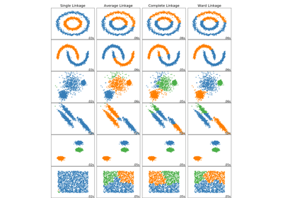

Comparing different hierarchical linkage methods on toy datasets

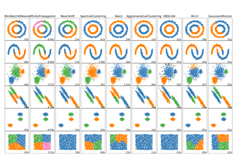

Comparing different clustering algorithms on toy datasets

© 2007–2018 The scikit-learn developers  
Licensed under the 3-clause BSD License.  
http://scikit-learn.org/stable/modules/generated/sklearn.cluster.AgglomerativeClustering.html